# Exp5:Standard Analysis

Mrudula

20th Jan 2021

#### This is the analysis of Experiment 5 to test for overshadowing effects in a contingency learning paradigm. This is a new paradigm that incorporates a visual search display with 8 stimuli presented in a circular way. The distractor display consists of 8 letters where 7 of them are in the same colour and one is in red acting as a salient distractor. The target display consisters of eight numbers where one of it will be 5 or an 8. Saliency is manipulated here by presenting this target number either in the same position of the salient word or at the position of the non salient word. All trials are learn trials wherein there is always a distractor display with the salient word

Loading the relevant libraries and dataframe

### Data cleaning and Preparation

- Removing unwanted columns
- Splitting the RT column to eliminate the first key in case of inaccurate trials
- creating a Column showing Accuracy and Error Rate

### Descriptives

Summary of the overall Reaction Time, accuracy and Error Rate

```r
pander(summary(Exp5data$RT_Trials), style = 'rmarkdown',caption = 'Mean RT')
```

Mean RT

| Min. | 1st Qu. | Median | Mean | 3rd Qu. | Max. |
| --- | --- | --- | --- | --- | --- |
| 1.725 | 668.4 | 910.3 | 1026 | 1250 | 20508 |

```r
pander(table(Exp5data$ACC_trials),style = 'rmarkdown',caption = "Accuracy")
```

Accuracy

| 0 | 1 |
| --- | --- |
| 837 | 13563 |

```r
pander(round(table(Exp5data$ACC_trials)/nrow(Exp5data)*100, digits = 3), style = 'rmarkdown', caption = "Percentage of errors")
```

Percentage of errors

| 0 | 1 |
| --- | --- |
| 5.812 | 94.19 |

Removing outliers and farouts

```
## [1] 837
```

```
## [1] 979
```

```
## [1] 1313
```

Summary of RT after removing Farouts

| Min. | 1st Qu. | Median | Mean | 3rd Qu. | Max. | NA’s |
| --- | --- | --- | --- | --- | --- | --- |
| 301.5 | 673.3 | 911.8 | 1013 | 1245 | 4313 | 979 |

Summary of RT after removing Outliers

| Min. | 1st Qu. | Median | Mean | 3rd Qu. | Max. | NA’s |
| --- | --- | --- | --- | --- | --- | --- |
| 301.5 | 667.6 | 900.4 | 981.4 | 1210 | 2992 | 1313 |

## Analysis

### 1. validity effect

#### Farouts

Comparing the difference between valid trials and invalid trials shows an unexpected trend where the invalid trials are faster than valid trials.

- **ANOVA**:

  | Effect | DFn | DFd | SSn | SSd | F | p | p<.05 | ges |
  | --- | --- | --- | --- | --- | --- | --- | --- | --- |
  | (Intercept) | 1 | 39 | 81210169 | 2287737 | 1384 | 4.417e-32 | * | 0.9718 |
  | Validity | 1 | 39 | 2581 | 68456 | 1.471 | 0.2326 |  | 0.001094 |

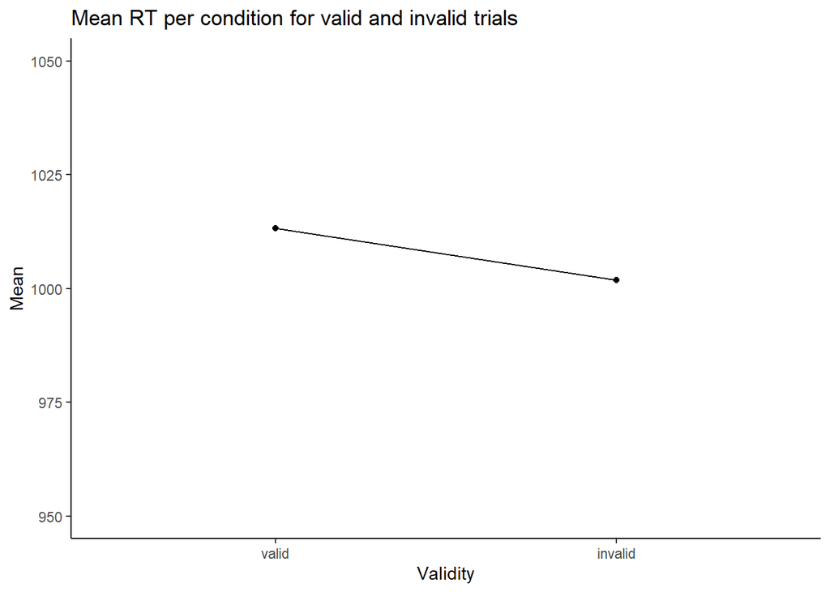

Here is the validity effect per participant

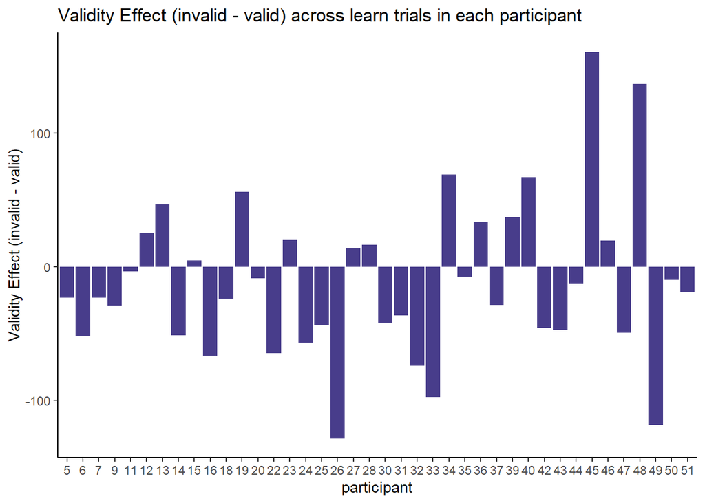

There are a decent amount of participants who show the trend of doing invalid trials faster than valid trials. Now to check how it looks with outliers exclusion

#### Outliers

- **ANOVA**:

  | Effect | DFn | DFd | SSn | SSd | F | p | p<.05 | ges |
  | --- | --- | --- | --- | --- | --- | --- | --- | --- |
  | (Intercept) | 1 | 39 | 76035912 | 2251037 | 1317 | 1.133e-31 | * | 0.9705 |
  | Validity | 1 | 39 | 2287 | 62805 | 1.42 | 0.2406 |  | 0.0009873 |

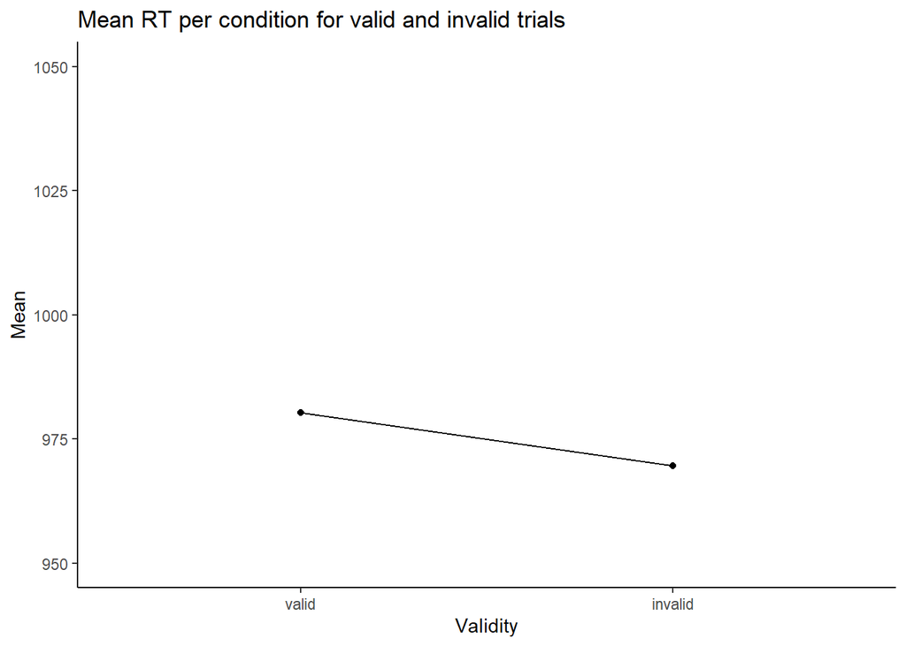

TO check how it is per participant:

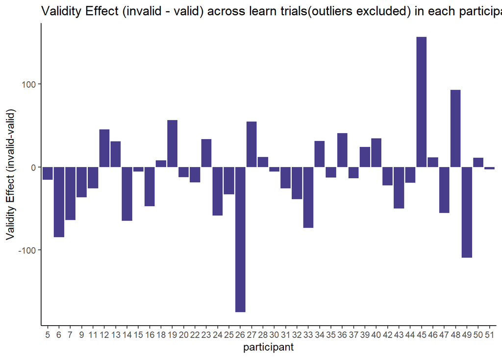

Participant 26 has a very strange trend, so excluding that participant alone to check for difference in data trends did not have any big impact except make the validity effect weaker. Considering both farouts and outliers, participants 6,26,33,49 were removed which resulted in valid and invalid trials to be very alike.

### 2. Saliency main effect

- **ANOVA**:

  | Effect | DFn | DFd | SSn | SSd | F | p | p<.05 | ges |
  | --- | --- | --- | --- | --- | --- | --- | --- | --- |
  | (Intercept) | 1 | 39 | 81888349 | 2211643 | 1444 | 1.984e-32 | * | 0.9626 |
  | PosMatch | 1 | 39 | 1007604 | 967497 | 40.62 | 1.571e-07 | * | 0.2407 |

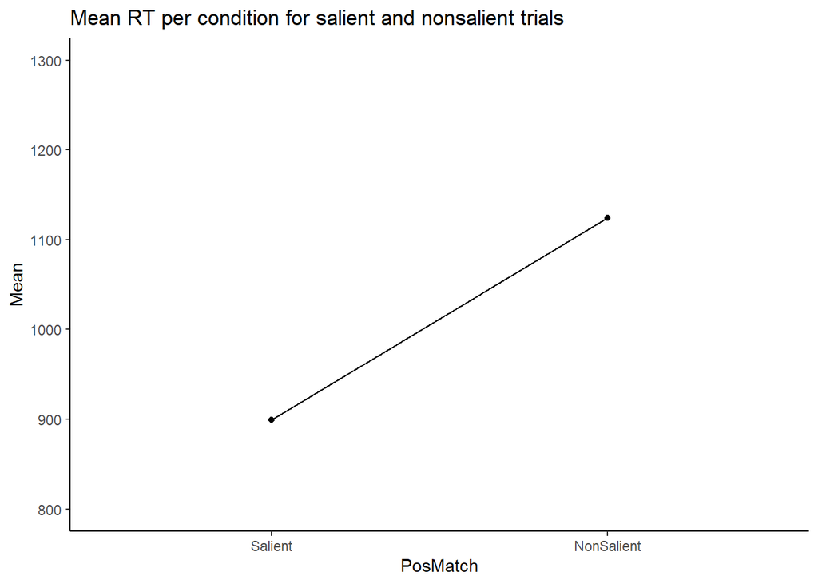

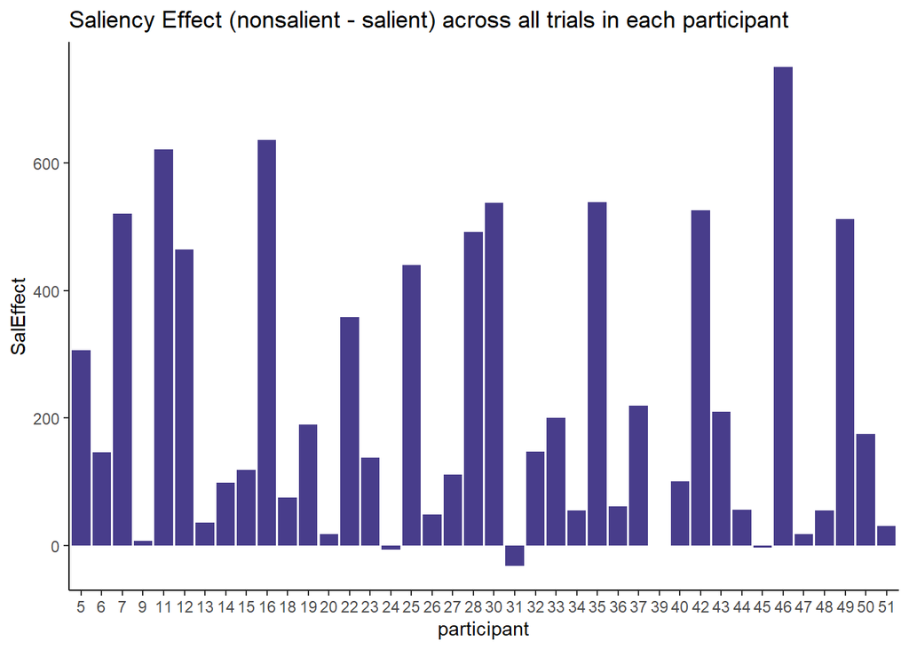

Considering the farouts, few participants show almost no saliency effect and one in the other direction. Namely participant 9,24,31,39,45.

- **ANOVA**:

  | Effect | DFn | DFd | SSn | SSd | F | p | p<.05 | ges |
  | --- | --- | --- | --- | --- | --- | --- | --- | --- |
  | (Intercept) | 1 | 39 | 76832806 | 2168310 | 1382 | 4.57e-32 | * | 0.9618 |
  | PosMatch | 1 | 39 | 881378 | 885220 | 38.83 | 2.471e-07 | * | 0.224 |

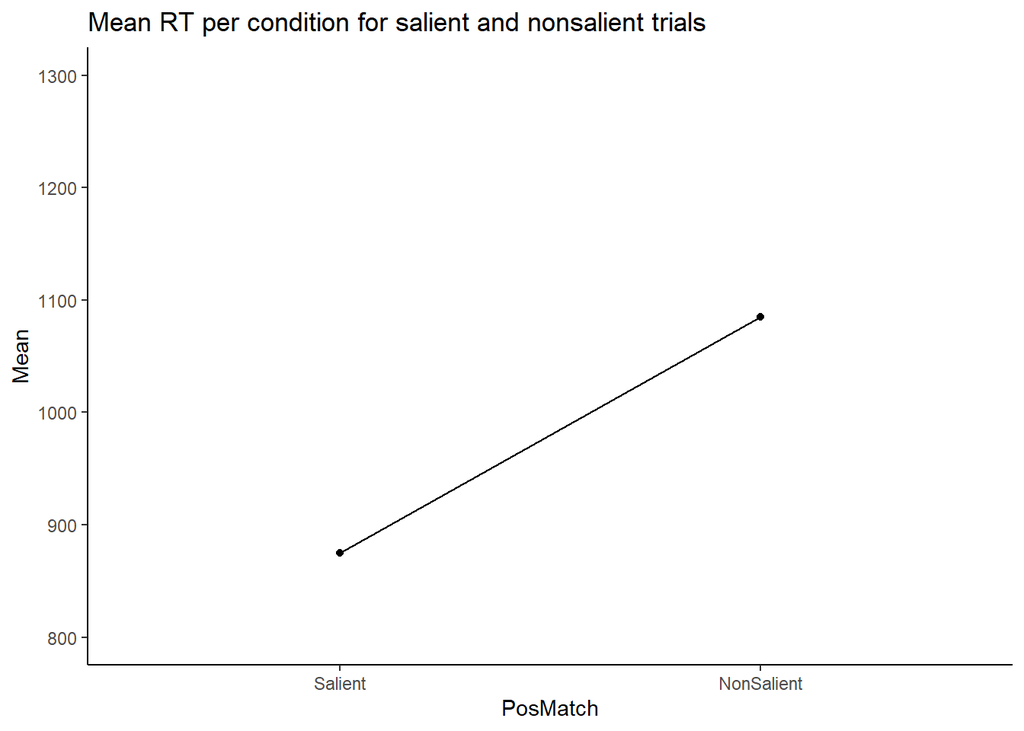

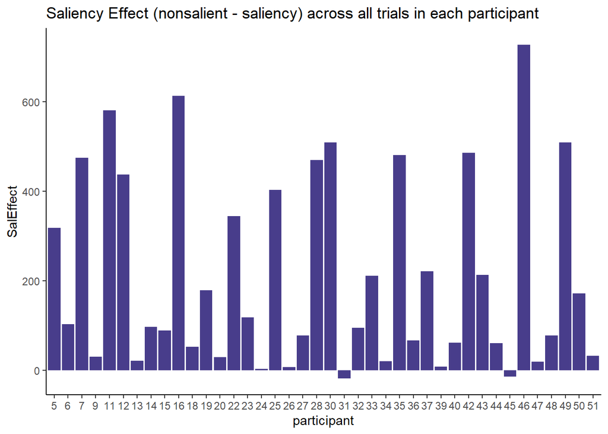

while looking at the data after exclusing outliers, some participants show a different trend in saliency where nonsalient trials are faster or do not differ so much: like participant 13,24,26,31,34,39,45,47.

We were curious to see whether this would impact the results and selected the participants with these unexpected trends Exploring data after removing these participants

### 3. Validity and Target position as a factor of Saliency

Comparing the difference in RTs for trials where target matched the salient distractor vs non salient distractors across valid and invalid trials

#### - Farouts

If we remove the particpiants who did not show an expected saliency effect then,the statistical effects are still identical to the one where all the participants were included with the exception that the Validity effect in the salient position further reduced.

- **ANOVA**:

  | Effect | DFn | DFd | SSn | SSd | F | p | p<.05 | ges |
  | --- | --- | --- | --- | --- | --- | --- | --- | --- |
  | (Intercept) | 1 | 39 | 162740157 | 4534315 | 1400 | 3.584e-32 | * | 0.9595 |
  | PosMatch | 1 | 39 | 1784983 | 2109341 | 33 | 1.171e-06 | * | 0.2062 |
  | Validity | 1 | 39 | 5399 | 138400 | 1.521 | 0.2248 |  | 0.0007851 |
  | PosMatch:Validity | 1 | 39 | 22255 | 88838 | 9.77 | 0.003344 | * | 0.003229 |

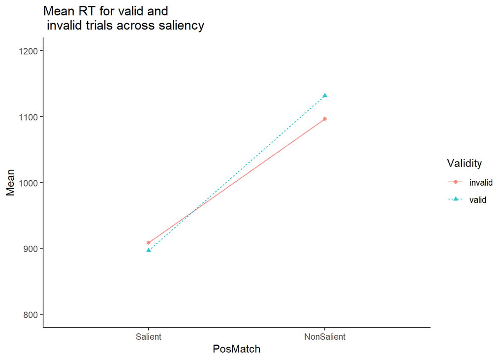

| PosMatch | N | Mean | SD | FLSD |
| --- | --- | --- | --- | --- |
| NonSalient | 40 | -35.21 | 70.39 | 30.53 |
| Salient | 40 | 11.97 | 81.84 | 30.53 |

#### While checking for trials where the position only matched with salient position

This shows the validity effect only in the trials where the target matched the salient position: T-test The difference is around 10ms

Paired t-test: `RT_ifo` by `Validity`

| Test statistic | df | P value | Alternative hypothesis | mean of the differences |
| --- | --- | --- | --- | --- |
| 0.925 | 39 | 0.3607 | two.sided | 11.97 |

#### - Outliers

The results are similar to the farouts

- **ANOVA**:

  | Effect | DFn | DFd | SSn | SSd | F | p | p<.05 | ges |
  | --- | --- | --- | --- | --- | --- | --- | --- | --- |
  | (Intercept) | 1 | 39 | 152683514 | 4433417 | 1343 | 7.845e-32 | * | 0.959 |
  | PosMatch | 1 | 39 | 1593477 | 1908036 | 32.57 | 1.322e-06 | * | 0.1961 |
  | Validity | 1 | 39 | 5168 | 124190 | 1.623 | 0.2102 |  | 0.0007907 |
  | PosMatch:Validity | 1 | 39 | 14076 | 65440 | 8.389 | 0.00616 | * | 0.002151 |

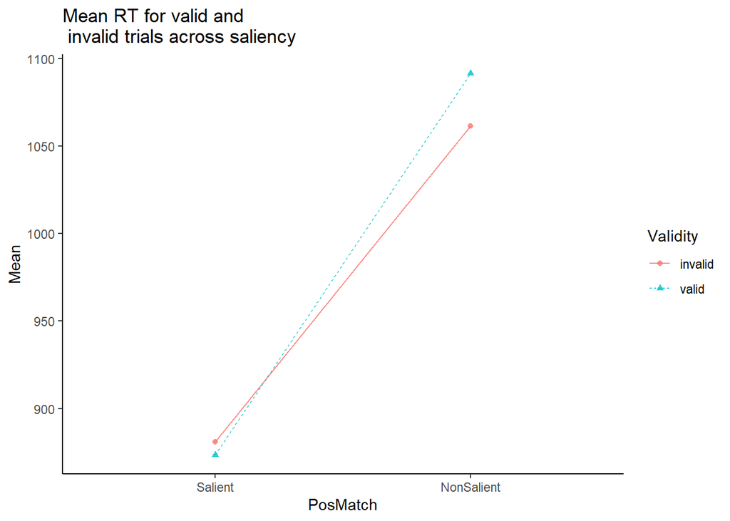

| PosMatch | N | Mean | SD | FLSD |
| --- | --- | --- | --- | --- |
| NonSalient | 40 | -30.13 | 63.01 | 26.2 |
| Salient | 40 | 7.392 | 75.86 | 26.2 |

Exploring the mean difference of valid and invalid trials separately for salient and non salient position

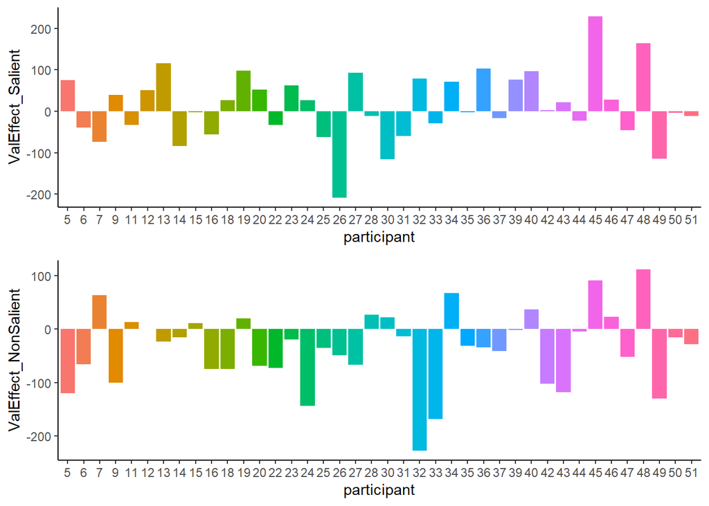

**So basically the faster invalid trials result from the nonsalient trials where the target is in the position of the non salient letter. However when it is in the salient letter’s position the valid trials are faster than invalid but not fast enough to have a validity effect in the expected direction.**

### Error Rate

While including all participants there is a main effect of Position Match however the other effects are not significant (the interaction is almost significant). Then the participants who did more than 15% errors were excluded.

- **ANOVA**:

  | Effect | DFn | DFd | SSn | SSd | F | p | p<.05 | ges |
  | --- | --- | --- | --- | --- | --- | --- | --- | --- |
  | (Intercept) | 1 | 39 | 0.5658 | 0.5877 | 37.54 | 3.446e-07 | * | 0.4512 |
  | PosMatch | 1 | 39 | 0.00796 | 0.03885 | 7.991 | 0.007379 | * | 0.01144 |
  | Validity | 1 | 39 | 0.0009298 | 0.03271 | 1.109 | 0.2988 |  | 0.001349 |
  | PosMatch:Validity | 1 | 39 | 0.002041 | 0.02888 | 2.756 | 0.1049 |  | 0.002957 |

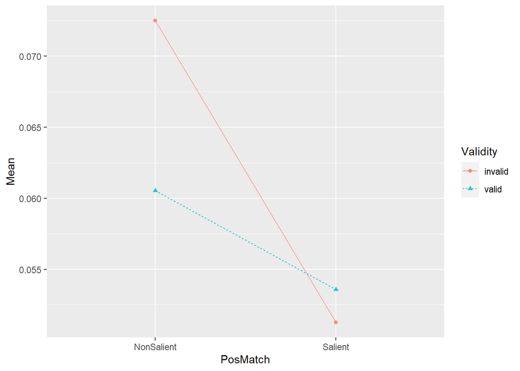

**Removing the participants with more errors from the standard analysis did not change the trend of the data.**

### Contingency Awareness

This part of analysis involves looking at the data concerning the awareness guessing trials and the questionnaire.

Below are the Scores of the participants in the Contingency Task. Red indicates number of Accurate Salient trials, blue indicates accuracy of nonsalient trials and the dark pink/purple is the count of both salient and non salient trials.

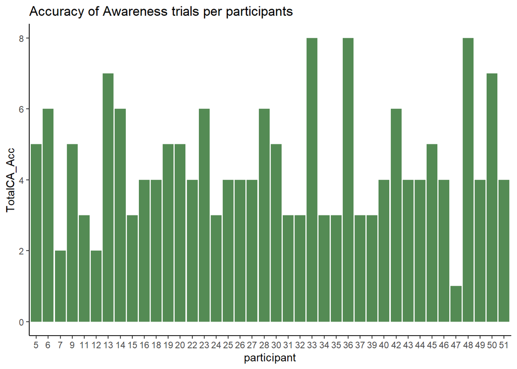

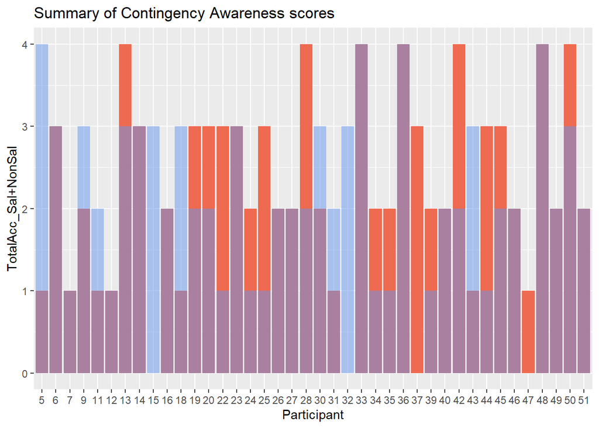

These show the scores from the guessing trials where some participants only got Salient position ones correct and some both salient and non salient positions. The next part of awareness report analysis is from the questionnaire where the participants answer a set of 5 questions as follows:

```
1.Did you have an impression that certain response appeared after a red letter? Press 'y' for yes and 'n' for no and 't' if you do not know.
2.What response almost always followed a red "V"? Press the relevant response key ("e" or "u") on the keyboard or press "t" if you do not know.
3.What response almost always followed a red "G"? Press the relevant response key ("e" or "u") on the keyboard or press "t" if you do not know.
4.What response almost always followed "L"?  Press the relevant response key ("e" or "u") on the keyboard or press "t" if you do not know.
5.What response almost always followed "X"? Press the relevant response key ("e" or "u") on the keyboard or press "t" if you do not know.
```

Now we aggregate the responses from these questions and evaluate it by combining question 2 and 3 that refer to salient distractors and 4 and 5 refer to non salient distractors

|  | 0 | 1 |
| --- | --- | --- |
| **0** | 23 | 17 |
| **1** | 20 | 20 |
| **2** | 19 | 21 |
| **3** | 37 | 3 |
| **4** | 36 | 4 |

Now we merge the participantID of those who were aware of both the salient letter-response associations with the aggregate dataframe used for analysis of the interaction effect.

- **ANOVA**:

  |  | Effect | DFn | DFd | SSn | SSd | F | p | p<.05 | ges |
  | --- | --- | --- | --- | --- | --- | --- | --- | --- | --- |
  | **1** | (Intercept) | 1 | 38 | 162740157 | 4506996 | 1372 | 1.972e-31 | * | 0.96 |
  | **2** | allSalAware | 1 | 38 | 27318 | 4506996 | 0.2303 | 0.634 |  | 0.004011 |
  | **3** | PosMatch | 1 | 38 | 1784983 | 2058057 | 32.96 | 1.291e-06 | * | 0.2083 |
  | **5** | Validity | 1 | 38 | 5399 | 134480 | 1.526 | 0.2244 |  | 0.0007952 |
  | **4** | allSalAware:PosMatch | 1 | 38 | 51285 | 2058057 | 0.9469 | 0.3367 |  | 0.007503 |
  | **6** | allSalAware:Validity | 1 | 38 | 3920 | 134480 | 1.108 | 0.2992 |  | 0.0005775 |
  | **7** | PosMatch:Validity | 1 | 38 | 22255 | 84247 | 10.04 | 0.003023 | * | 0.00327 |
  | **8** | allSalAware:PosMatch:Validity | 1 | 38 | 4591 | 84247 | 2.071 | 0.1583 |  | 0.0006763 |

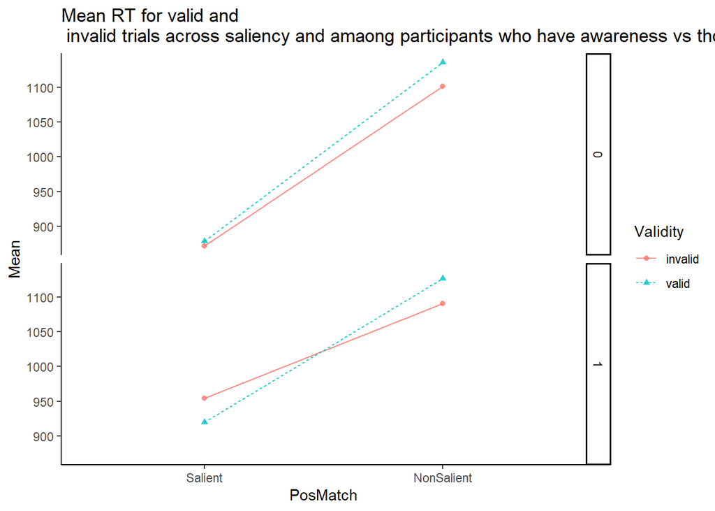

#### While analyzing only participants with awareness

- **ANOVA**:

  | Effect | DFn | DFd | SSn | SSd | F | p | p<.05 | ges |
  | --- | --- | --- | --- | --- | --- | --- | --- | --- |
  | (Intercept) | 1 | 17 | 75346036 | 2420749 | 529.1 | 3.008e-14 | * | 0.9551 |
  | PosMatch | 1 | 17 | 530406 | 1001548 | 9.003 | 0.008046 | * | 0.1302 |
  | Validity | 1 | 17 | 8.161 | 82653 | 0.001679 | 0.9678 |  | 2.302e-06 |
  | PosMatch:Validity | 1 | 17 | 22597 | 39954 | 9.615 | 0.006494 | * | 0.006334 |

| PosMatch | N | Mean | SD | FLSD |
| --- | --- | --- | --- | --- |
| NonSalient | 18 | -36.1 | 83.4 | 48.22 |
| Salient | 18 | 34.76 | 86.43 | 48.22 |